# Statistical Inference – Part 2

[Ryan Lei](https://www.coursera.org/user/i/adc3888c696d25d769137c26e7006fd8)

January 25, 2015

### Introduction

In this exercise, we will perform a basic inferential data analysis on the **ToothGrowth** dataset built in R.

### Exploratory Data Analysis

From the help page of command `?ToothGrowth`, we know that this dataset measures the tooth lengths of 10 Guinea pigs grouped by **2 supplement types** of vitamim C: orange juice (OJ) and ascorbic acid (VC), and **3 dose levels**: 0.5, 1.0, and 2.0 mg.

Let’s see what the dataset looks like:

```r
head(ToothGrowth, 3)
```

```
##    len supp dose
## 1  4.2   VC  0.5
## 2 11.5   VC  0.5
## 3  7.3   VC  0.5
```

```r
# Count the number of observations in each group
with(ToothGrowth, table(supp, dose))
```

```
##     dose
## supp 0.5  1  2
##   OJ  10 10 10
##   VC  10 10 10
```

Indeed, there are 10 observations in each of the 6 groups: 2 supplement types * 3 dose levels.

Let’s compare the *means* by summarizing each group:

```r
xtabs(len ~ supp + dose, aggregate(len ~ supp + dose, ToothGrowth, mean))
```

```
##     dose
## supp   0.5     1     2
##   OJ 13.23 22.70 26.06
##   VC  7.98 16.77 26.14
```

Presented graphically, here’s a conditioning plot provided in the help page, with the **red** lines being the means in the above table:

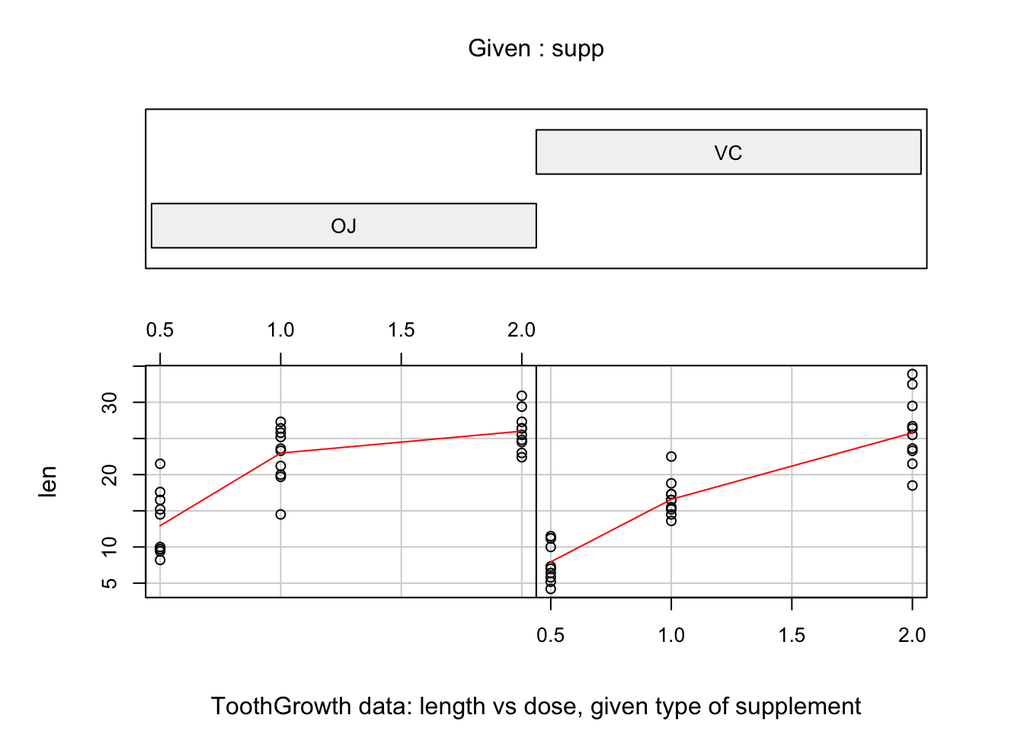

```r
require(graphics)
coplot(len ~ dose | supp, data = ToothGrowth, panel = panel.smooth,
       xlab = "ToothGrowth data: length vs dose, given type of supplement")
```

### Confidence Intervals and Hypothesis Tests

In this exercise, we will assume the 10 Guinea pigs are *NOT paired*, i.e., the Guinea pig #1 in one group is different from the Guinea pig #1 in another group. Therefore, they are treated as **independent groups**. Also, we will assume **unequal population variances** across groups because we are not given such information.

First, we subset the dataset into different variables for easier references.

```r
OJ_05 <- subset(ToothGrowth, supp == "OJ" & dose == 0.5)$len
OJ_10 <- subset(ToothGrowth, supp == "OJ" & dose == 1.0)$len
OJ_20 <- subset(ToothGrowth, supp == "OJ" & dose == 2.0)$len
VC_05 <- subset(ToothGrowth, supp == "VC" & dose == 0.5)$len
VC_10 <- subset(ToothGrowth, supp == "VC" & dose == 1.0)$len
VC_20 <- subset(ToothGrowth, supp == "VC" & dose == 2.0)$len
```

In this exercise, we set all significance levels $\alpha$ to 5% to derive 95% confidence intervals. Because the exploratory data analysis showed a nice intuition that generally $\mu_{OJ}$ > $\mu_{VC}$ and $\mu_{higher.dose}$ > $\mu_{lower.dose}$, all the comparisons will be done in **one-sided T tests** on differences in group means.

**We will reject the null hypothesis if *zero* is outside the 95% confidence interval, or equivalently, p-value < 0.05.**

**(1.1) At dose = 0.5 ——— $H_0$: $\mu_{OJ}$ = $\mu_{VC}$, $H_a$: $\mu_{OJ}$ > $\mu_{VC}$**

```r
test11 <- t.test(OJ_05, VC_05, alternative = "greater", paired = F, var.equal = F)
list(confidence.interval = test11$conf.int, p.value = test11$p.value)
```

```
## $confidence.interval
## [1] 2.34604     Inf
## attr(,"conf.level")
## [1] 0.95
##
## $p.value
## [1] 0.003179303
```

- Result: Reject $H_0$ in favor of $H_a$.

**(1.2) At dose = 1.0 ——— $H_0$: $\mu_{OJ}$ = $\mu_{VC}$, $H_a$: $\mu_{OJ}$ > $\mu_{VC}$**

```r
test12 <- t.test(OJ_10, VC_10, alternative = "greater", paired = F, var.equal = F)
list(confidence.interval = test12$conf.int, p.value = test12$p.value)
```

```
## $confidence.interval
## [1] 3.356158      Inf
## attr(,"conf.level")
## [1] 0.95
##
## $p.value
## [1] 0.0005191879
```

- Result: Reject $H_0$ in favor of $H_a$.

**(1.3) At dose = 2.0 ——— $H_0$: $\mu_{OJ}$ = $\mu_{VC}$, $H_a$: $\mu_{OJ}$ > $\mu_{VC}$**

```r
test13 <- t.test(OJ_20, VC_20, alternative = "greater", paired = F, var.equal = F)
list(confidence.interval = test13$conf.int, p.value = test13$p.value)
```

```
## $confidence.interval
## [1] -3.1335     Inf
## attr(,"conf.level")
## [1] 0.95
##
## $p.value
## [1] 0.5180742
```

- Result: **Do not** reject $H_0$.

**(2.1) At supp = OJ ——— $H_0$: $\mu_{0.5}$ = $\mu_{1.0}$, $H_a$: $\mu_{0.5}$ < $\mu_{1.0}$**

```r
test21 <- t.test(OJ_05, OJ_10, alternative = "less", paired = F, var.equal = F)
list(confidence.interval = test21$conf.int, p.value = test21$p.value)
```

```
## $confidence.interval
## [1]      -Inf -6.214316
## attr(,"conf.level")
## [1] 0.95
##
## $p.value
## [1] 4.39246e-05
```

- Result: Reject $H_0$ in favor of $H_a$.

**(2.2) At supp = VC ——— $H_0$: $\mu_{0.5}$ = $\mu_{1.0}$, $H_a$: $\mu_{0.5}$ < $\mu_{1.0}$**

```r
test22 <- t.test(VC_05, VC_10, alternative = "less", paired = F, var.equal = F)
list(confidence.interval = test22$conf.int, p.value = test22$p.value)
```

```
## $confidence.interval
## [1]      -Inf -6.746867
## attr(,"conf.level")
## [1] 0.95
##
## $p.value
## [1] 3.405509e-07
```

- Result: Reject $H_0$ in favor of $H_a$.

**(2.3) At supp = OJ ——— $H_0$: $\mu_{1.0}$ = $\mu_{2.0}$, $H_a$: $\mu_{1.0}$ < $\mu_{2.0}$**

```r
test23 <- t.test(OJ_10, OJ_20, alternative = "less", paired = F, var.equal = F)
list(confidence.interval = test23$conf.int, p.value = test23$p.value)
```

```
## $confidence.interval
## [1]       -Inf -0.7486236
## attr(,"conf.level")
## [1] 0.95
##
## $p.value
## [1] 0.01959757
```

- Result: Reject $H_0$ in favor of $H_a$. (not as significant as other tests, though)

**(2.4) At supp = VC ——— $H_0$: $\mu_{1.0}$ = $\mu_{2.0}$, $H_a$: $\mu_{1.0}$ < $\mu_{2.0}$**

```r
test24 <- t.test(VC_10, VC_20, alternative = "less", paired = F, var.equal = F)
list(confidence.interval = test24$conf.int, p.value = test24$p.value)
```

```
## $confidence.interval
## [1]      -Inf -6.346525
## attr(,"conf.level")
## [1] 0.95
##
## $p.value
## [1] 4.577802e-05
```

- Result: Reject $H_0$ in favor of $H_a$.

### Conclusions

In this experiment, we are trying to test the effect of supplementing **different types** and **different dose levels** of vitamin C on the tooth lengths of 10 Guinea pigs. We assume the hypothesis tests are done with independent groups, i.e., the Guinea pigs are not paired. We also assume unequal population variances across groups. At a 95% significance level ($\alpha$ = 0.05), we perform one-sided T tests to see if:

- The effect of supplementing orange juice (OJ) is greater than that of supplementing ascorbic acid (VC).
- The effect of a higher dose level is greater than that of a lower dose level.

According to the above 7 hypothesis tests, **our intuitions are quite correct.**

In comparing the two supplement types (Test 1.1 to 1.3), the means of OJ are statistically greater than the means of VC at dose = 0.5 and 1.0, with p-values of $3 \times 10^{-3}$ and $5 \times 10^{-4}$. But at dose = 2.0, OJ no longer outperforms VC, with p-value = 0.5181.

In comparing the three dose levels (Test 2.1 to 2.4), ALL the means of higher dose levels are statistically greater than the means of lower dose levels, with generally *even lower* p-values from $3 \times 10^{-7}$ to $4 \times 10^{-5}$. However, in comparing $\mu_{1.0}$ and $\mu_{2.0}$ when supp = OJ (Test 2.3), although we still reject $H_0$, the p-value jumps up to 0.0196, the highest of the 6 tests where we reject $H_0$.